# 01-Baby steps

Corsi ARCA

## Creare un nuovo file `RMarkdown`

Easy peasy 🍋 squeezy:

[figure not shown]

[figure not shown]

## Default file `RMarkdown`

Come prima cosa, appare questo:

```r
---
title: "Esempio di File di testo"
author: "Ottavia M. Epifania"
date: "19/05/2024"
output: html_document
---
```

Questo è l’header YAML ed è dove andiamo a definire il tipo di file che vogliamo, il titolo, l’autore, la data.

Per compilare il file si può premere sul tasto **knit** oppure si può usare la combo di tasti `shift + ctrl + k` (per chi ha il Mac `shift + cmd + k`)

Siccome nel nostro header abbiamo `output: html_document` (il default), il file compilato sarà un file `html`

## Visual vs. source

### Visual

[figure not shown]

### Source

[figure not shown]

## Your turn!

- Create un nuovo file
- Date un titolo a scelta
- Cliccate “knit”!

ADAVANCED

- Mettete un sottotitolo
- Togliete la data

## Dettagli sulla compilazione

Si può scegliere il tipo di file da compilare cambiando da `output: html_document` a `output: pdf_document` (Questa operazione si può svolgere anche cliccando sulla freccina accanto a **knit** e selezionando “Knit to PDF”)

Nel caso abbiate seguito la seconda strada, viene modificato lo YAML del file:

```r
---
title: "Esempio di File di testo"
author: "Ottavia M. Epifania"
date: "19/5/2024"
output:
  pdf_document: default
  html_document: default
---
```

Ma non preoccupatevi, è la stessa cosa!

Se non viene modificato troppo il default, si può saltellare tra html e pdf più volte!

## Tutti per lo YAML, uno YAML per tutto

Nello YAML andiamo ad indicare varie specifiche del nostro file (che vedremo in seguito).

Per ora, aggiungiamo un sottotitolo:

```r
---
title: "Esempio di File di testo"
subititle: "Ecco il sottotitolo"
author: "Ottavia M. Epifania"
date: "19/5/2024"
output:
  pdf_document: default
  html_document: default
---
```

## Si possono pure togliere pezzi

La data non sta molto bene: Provate a toglierla!

```r
---
title: "Esempio di File di testo"
subititle: "Ecco il sottotitolo"
author: "Ottavia M. Epifania"
date: ""
output:
  pdf_document: default
  html_document: default
---
```

## Gli headers

## Cosa sono

Sono i titoli delle sezioni, sottosezioni e dei paragrafi

```
# Header 1

## Header 2

### Header 3

#### Header 4
```

Titolo di una sezione

Titolo di una sottosezione

Titolo della sotto-sottosezione (seriously)

Titolo del paragrafo

## Come si usano

```
# Header 1

Muoio senza morire, in questi giorni usati
```

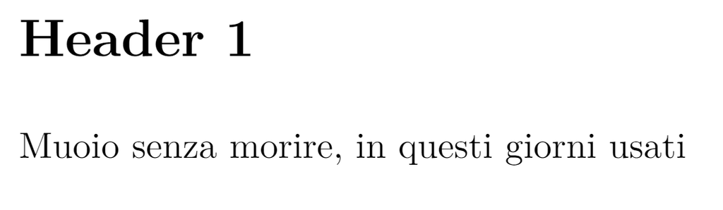

Anche tutti gli altri header funzionano così, ad eccezione di `#### Header 4`

```
#### Titolo di un paragrafo

Testo del paragrafo molto importante
```

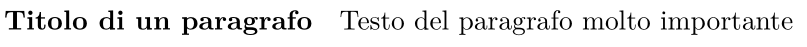

## I numeri di sezione

Per aggiungere i numeri delle sezioni, basta aggiungere allo YAML: `number_sections: true`:

```r
---
title: "Esempio di File"
subtitle: Sottotitolo
date: "19/5/2024"
author: Ottavia M. Epifania
output:
  pdf_document:
    number_sections: true
---
```

(fate attenzione all’indentazione)

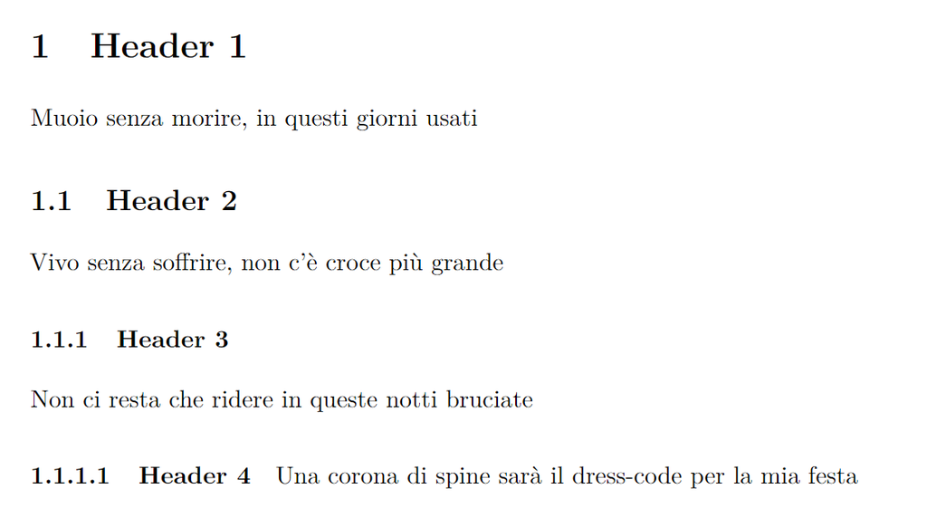

## Table of contents

## Your turn

- Creare un documento
- Usare il nome del vostro dataset come titolo
- Sottotitolo a scelta
- Al posto della data \(\rightarrow\) Università di Padova

ADAVANCED

- Aggiungere almeno 3 headings (e.g., “Titolo 1”, “Titolo 2”, “Titolo 3”)
- Table of contents (hint: `toc: true`)

## Formattazione del testo

## Interlinea & Margini

YAML:

```r
---
output:
  pdf_document:
   number_sections: true
      toc: true
      toc_depth: 1
linestretch: 1.5
geometry: margin=1in
lang: it
---
```

## Corsivo, grassetto, corsetto, colori

```
*Corsivo*

**Grassetto**

***Corsetto***

\textcolor{red}{Parola colorata (PDF)}

\color{red}{Anche così}\normalcolor

<span style="color:red">Parola colorata (HTML)</span>
```

*Corsivo*

**Grassetto**

*Corsetto*

Parola colorata (PDF)

Anche così (PDF)

Parola colorata (HTML)

## Ingrandire e rimpicciolire il testo

### Valido solo per i pdf

[figure not shown]

## Your turn!

- Modificare i margini del documento a 0.5in
- Impostare l’interlinea di un punto e mezzo
- Mettere delle parole in *corsivo*, **grassetto** e *corsetto*
- Aggiungere delle parole colorate

ADAVANCED

- Aggiungere una **parola colorata** in **grassetto**
- Aggiungere una *parola colorata* in *corsivo*
- Aggiungere una *parola colorata* in *corsetto*

## Block quote

Molto semplicemente, si fa precedere il testo da `>`:

```
Una canzone di Ghali, presentata a Sanremo 2024.

>  Il prato è verde, più verde, più verde, sempre più verde (sempre più verde).
Il cielo è blu, blu, blu, molto più blu (ancora più blu)
```

[figure not shown]

## Elenchi

### Unordered list

```
- Sinceramente
- Quella di Geolier
- Casa mia
- La noia
```

- Sinceramente
- Quella di Geolier
- Casa mia
- La noia

### Ordered list

```
1. La noia
2. Quella di Geolier
3. Sinceramente
4. Casa mia
```

1. La noia
2. Quella di Geolier
3. Sinceramente
4. Casa mia

## Elenchi annidati

```
- Un elenco
    - Voce del secondo elenco
    - altra voce del secondo elenco
- Seconda voce del primo elenco
```

- Un elenco
  - Voce del secondo elenco
  - altra voce del secondo elenco
- Seconda voce del primo elenco

## Note

Nulla di più semplice:

```
Con i piedi[^1]

[^1]: ciao ciao

Un sacco di testo nel mio file
```

[figure not shown]

## Link

```
[Parola](url-della-pagina)

[Tuta Gold](https://youtu.be/Pz168-XMNIk?si=kLpXXP8rJfAj6cMu) è una canzone che parla di
una tuta che è gold
```

[Tuta Gold](https://youtu.be/Pz168-XMNIk?si=kLpXXP8rJfAj6cMu) è una canzone che parla di una tuta che è gold

## Your turn

- Creare una unordered list
- Creare una ordered list
- Annidare una unordered list in una ordered list

ADAVANCED

- Mettere due note a piè di pagina
- In una delle due note metter un link a una pagina wikipedia connessa al vostro dataset

## Inserire immagini

## `Markdown` style vs. `RMarkdown` PT. I

#### `Markdown`

`![Caption](percorso-alla-figura)`

[figure not shown]

Prima del corso `RMarkdown`

#### `RMarkdown`

````
```{r, fig.cap = "Caption", fig.align="center", out.width="50%"}
knitr::include_graphics(path = "percorso-alla-figura")
```
````

[figure not shown]

Dopo il corso `RMarkdown`

`fig.align` (cambia l’allineamento della figura), `out.width` (cambia la dimensione dell’immagine modificandone la larghezza, l’altezza si adatta automaticamente)

## `Markdown` style vs. `RMarkdown` PT. II

#### `Markdown`

😄 Più immmediato

😄 Si “autoaggiusta” al file (non sempre in modo ottimale)

🥹 Per cambiare qualcosa bisogna ricorrere a HTML

#### `RMarkdown`

😄 Permette di cambiare comodamente posizionamento e dimensioni dell’immagine

😞 Richiede un po’ di scrittura in più

## Le sottocartelle

## Perché

In Word o simili siamo abituati a mettere “a mano” le figure, magari anche la bibliografia \(\rightarrow\) si mette tutto nel file di testo

In `RMarkdown`, le immagini, la bibliografia, gli eventuali dati e i risultati delle analisi devono essere importati all’interno del file

L’importazione è basata sui “percorsi” (le directory) dei file.

## Come

Fondamentalmente in due modi:

1. Il file che ci interessa è nella stessa cartella del file su cui stiamo lavorando:
   - Questa opzione va bene se abbiamo pochi file da importare
   - Ad ogni modo questa non è una soluzione ottimale \(\rightarrow\) troppo disordine
2. Si creano delle sottocartelle divise per tema (e.g., immagini, bibliografia, dati) \(\rightarrow\) è la soluzione ottimale che permette di avere tutti i file a disposizione e organizzati in modo lineare

## Un esempio

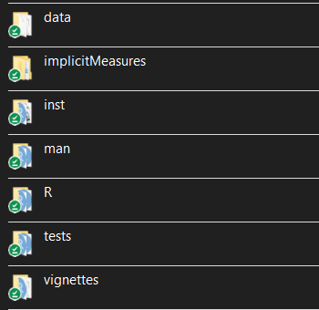

Se volessi importare un’immagine nel mio documento chiamata “immagine.png” contenuta nella cartella “vignettes” dovrei scrivere:

````
```{r, fig.cap = "Caption", fig.align="center", out.width="50%"}
knitr::include_graphics(path = "vignettes/immagine.png")
```
````

(Funziona anche usando il codice `![Caption](vignettes/immagine.png)`)

## Your turn!

- Nel vostro progetto, create la cartella `img` e la cartella `bibliografia`
- Scegliete due immagini da Google immagini (magari inerenti il vostro dataset 🐔, 🌹, 🚗) e salvatele nelle cartella `img`
- Importare le immagini, una con il codice `Markdown`, una con il codice `RMarkdown`

ADVANCED

- Importare di nuovo una delle due immagini e allinearla a destra
- Importare di nuovo l’altra immagine e ridurre la dimensione al 10%

## Bibliografia

## Torniamo allo YAML

```
output:
  pdf_document:
  keep_tex: yes
   number_sections: true
   toc: true
   toc_depth: 1
linestretch: 1.5
geometry: margin=1in
bibliography: biblio.bib
```

Ecco fatto, messa la bibliografia!

Ovviamente, il file `biblio.bib` va creato ex-novo.

Se si usa questo codice, la bibliografia deve essere nella stessa cartella del file che stiamo creando. Se invece è in una sottocarella `bibliography: bibliografia/biblio.bib`

## Creare `.bib`

`.bib` è l’estensione del file. Sia `R` sia `LaTeX` riconoscono i file `.bib` come file di bibliografia.

1. Si decide qual è la letteratura rilevante per quello che stiamo facendo
2. si va su Google scholar e si copia la citazione in formato `BibTex`:

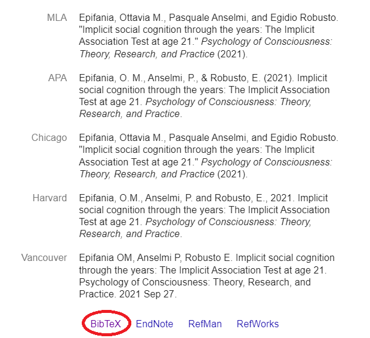

3. La citazione risulta essere:

````
```
@article{epifania2021implicit,
title={Implicit social cognition through the years: The Implicit Association Test at age 21.},
author={Epifania, Ottavia M and Anselmi, Pasquale and Robusto, Egidio},
journal={Psychology of Consciousness: Theory, Research, and Practice},
year={2021},
doi={https://doi.org/10.1037/cns0000305},
publisher={Educational Publishing Foundation}
}
```
````

4. La copiaincolliamo in un documento vuoto (il blocco note va benissimo)
5. Salviamo il documento con un nome a scelta (e.g., `biblio`) **ma soprattutto** ricordando l’estensione `.bib`

❗ `epifania2021implicit` è la “chiave” che ci permette di citare l’articolo nel testo

In fondo al file `# Bibliografia`

## Come citare nel testo

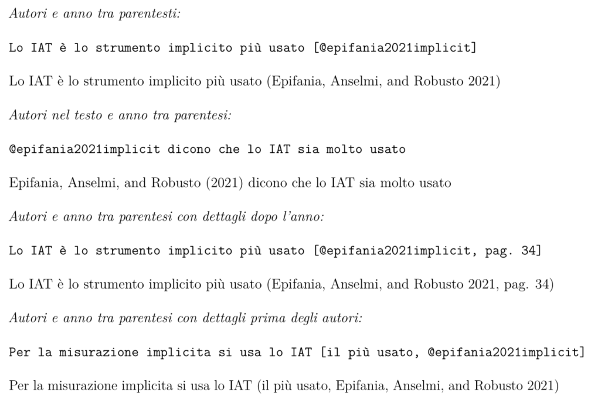

## Your turn

- Creare un file `.bib` che contenga questi due articoli su Google Scholar:
  - *DscoreApp: a shiny web application for the computation of the implicit association test d-score*
  - *Implicit measures with reproducible results: The implicitMeasures package*
- Salvare il file nella cartella `bibliografia` creata in precedenza
- Usare entrambe le citazioni con Autori e anno tra parentesi

ADVANCED

- Sbizzarritevi con le citazioni

## La matematica (non sarà mai il mio mestiere)

## Equazioni

Le equazioni vengono risconosciute dal simbolo `$`.

### Inline equation

`$3 +2 =5$` risulta in \(3+2=5\), sulla stessa riga del testo che si sta scrivendo

### Equation

Per scrivere le equazioni come blocchi di testo a parte, si usa il doppio dollaro. `$$3 +2 =5$$` diventa \[3+2=5\] (anche se lo scrivo sulla stessa riga!)

## Lettere greche, frazioni e simili

Per inserire le lettere greche, basta scrivere la lettera greca che si desidera in caratteri latini all’interno dei dollari, preceduta da `\`.

Più semplicente, se vogliamo \(\delta\), non dobbiamo far altro che scrivere `$\delta$`

Se si vogliono le lettere greche maiuscolo, si mette in maiuscolo la prima lettera latina, per cui `$\Delta$` risulta in \(\Delta\)

`$\frac{num}{den}$` permette di scrivere le frazioni (`$\frac{2}{3}$` \(\rightarrow\) \(\frac{2}{3}\))

`$\sqrt{numero}$` è la radice quadrata (`$\sqrt{4}$` \(\rightarrow\) \(\sqrt{4}\))

A [questa pagina](https://artofproblemsolving.com/wiki/index.php/LaTeX:Symbols) trovate una lista esaustiva dei simboli matematici

## Tutto molto bello, ma….?

## Ma come si metteno le cross-referencing?

Con `RMarkdown` base (quello che stiamo usando noi), si può usando LaTeX

`bookdown` ci permette di fare cross-references alle equazioni, alle figure (generate da codice) e alle tabelle:

```r
install.packages("bookdown")
```

E modifichiamo l’output nello YAML in:

```r
 output:
  bookdown::pdf_document2:
    keep_tex: yes
    number_sections: yes
    toc: yes
    toc_depth:
    [...]
```

Il comando nel testo:

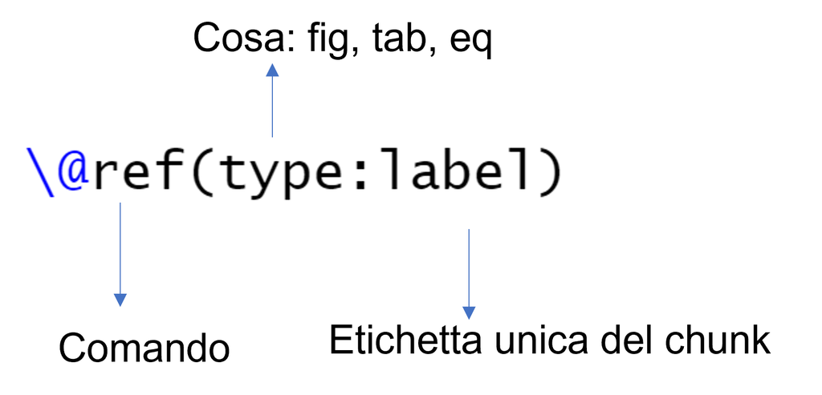

Nella breve lezione su [LaTeX](https://arca-dpss.github.io/CorsoRmarkdown/slides/04%20-%20LaTeX-knitr/04-LaTeX-knitr.pdf) vedremo come usare al meglio e soprattutto in modo flessibile le cross-references

## Cross-referencing: La tabella

La tabella deve essere generata dal codice di `R`

Unfortunately, `stargazer` e `bookdown` non si parlano. A [questa pagina](https://github.com/rstudio/bookdown/issues/175) discutono di come integrare i due pacchetti ma non funziona

Usiamo `kable`:

````
```{r cars-table}
knitr::kable(mtcars[1:5, ], caption = "Questo è un dataset")
```
````

Per richiamare nel testo `\@ref(tab:cars-table)`.

## Cross-referencing: I plot

Funziona solo con la funzione base `plot`:

````
```{r speed-dist, fig.cap="Grafico mpg-cilindrata"}
par(mar = c(4, 4, .2, .1))
plot(mtcars$mpg ~ mtcars$cyl)  # a boxplot
```
````

Per richiamrla nel testo `\@ref(fig:speed-dist)`

## Cross-referencing: Le equazioni

Molto semplicemente:

```r
\begin{equation}
\bar{X} = \frac{\sum_{i=1}^n X_i}{n} (\#eq:media)
\end{equation}
```

Per richiamarla nel testo `\@ref(eq:media)`